# HW1 Rewrite

2024-12-06

*Q2.*

```r
#2.
library(readr)
library(tidyverse)
client_list <- read_csv("C:\\Users\\Ava\\Desktop\\R\\HW1\\client_list.csv")
```

```
## ──────────────────────────────────────────────────────── Delimiter: "," chr
## (2): Membership, Gender dbl (3): ...1, Client, Age
```

```r
salesdata <- read_csv("C:\\Users\\Ava\\Desktop\\R\\HW1\\salesdata.csv")
```

```
## ──────────────────────────────────────────────────────── Delimiter: "," chr
## (2): Store, Region dbl (5): ...1, Product, Client, UnitPrice, Quantity
```

```r
product_list <- read_csv("C:\\Users\\Ava\\Desktop\\R\\HW1\\product_list.csv")
#(1.)
product_list1 <- separate(product_list,Item,into = c("Product","Item"),sep = "_",,convert=TRUE)
#(2.)
library(dplyr)
salesdata_sorted <- salesdata %>% arrange(Client)
salesdata_sorted  %>% left_join(client_list,by="Client") -> merge1
merge1  %>% left_join(product_list1,by="Product") -> full_table
full_table
```

```
## # A tibble: 100 × 12
##    ...1.x Store Product Client UnitPrice Quantity Region ...1.y   Age Membership
##     <dbl> <chr>   <dbl>  <dbl>     <dbl>    <dbl> <chr>   <dbl> <dbl> <chr>
##  1      1 A         103      1        10       72 Brazil      1    36 basic
##  2     25 A         103      1        18       26 Korea       1    36 basic
##  3     28 C         105      1        11        4 Japan       1    36 basic
##  4     10 A         103      2        14       58 China       2    46 diamond
##  5     11 C         101      2         8       35 Brazil      2    46 diamond
##  6     41 B         105      2         4       76 Korea       2    46 diamond
##  7     59 B         101      2         7       58 Korea       2    46 diamond
##  8     67 B         105      2        14       98 Thail…      2    46 diamond
##  9     84 C         105      2        14       59 Germa…      2    46 diamond
## 10     97 B         105      2         9       20 Brazil      2    46 diamond
## # ℹ 90 more rows
## # ℹ 2 more variables: Gender <chr>, Item <chr>
```

```r
#(3.)
library(tidyverse)
full_table%>%
  mutate( Spend = UnitPrice*Quantity ) -> full_table1
```

*4. 在full.table將會員等級分組，其中gold和diamond的顧客為一組，其他等級的為一組，針對兩組客戶進行比較介紹（例如平均年紀、性別、國家、消費情況差異等）。*

2-4：無文字敘述分析 -5(需對你跑出的結果進行分析或洞察)

```r
#分組
full_table2 <- full_table1 %>%
  mutate(Group = ifelse(Membership %in% c("gold", "diamond"), "Gold & Diamond", "Other"))
```

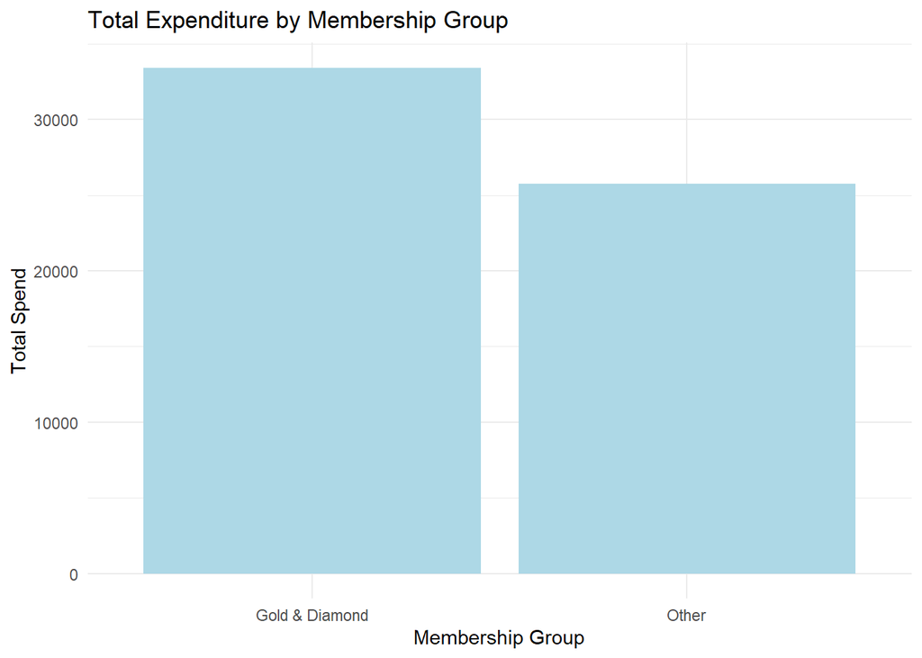

```r
ggplot(full_table2, aes(x = Group, y = Spend)) +
  geom_col(fill = "lightblue") +
  labs(
    title = "Total Expenditure by Membership Group",
    x = "Membership Group",
    y = "Total Spend"
  ) +
  theme_minimal()
```

根據上圖分析結果，Gold & Diamond 會員在此電商公司的消費高於其他等級的消費者，顯示目前的經營策略和分組是有效的。 此電商公司可根據目前已知數據進行策略優化，大致可分為兩個方向：加強對Gold & Diamond 會員的忠誠計劃、針對其他會員等級的升級策略。

1. 加強對Gold & Diamond 會員的忠誠計劃 (1.)個性化優惠與折扣：根據他們的消費習慣，定期發送個性化的優惠券或折扣，以增加再次購買的可能性。 (2.)專屬活動或禮遇：為 Gold & Diamond訂製專屬活動例如新產品預覽、私人定制服務等，以加強他們的品牌歸屬感。
2. 針對其他會員等級的升級策略 可定期舉辦促銷活動，如達到一定消費額就可升級為更高等級並獲得相應的福利。

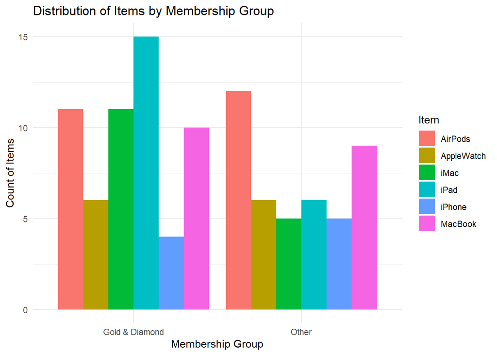

```r
ggplot(full_table2, aes(x = Group, fill = Item)) +
  geom_bar(position = "dodge") +
  labs(
    title = "Distribution of Items by Membership Group",
    x = "Membership Group",
    y = "Count of Items"
  ) +
  theme_minimal()
```

1.針對 iMac 和 iPad 的專屬營銷策略 (1.)專屬優惠：為 Gold & Diamond 會員提供 iMac 和 iPad 的專屬折扣或促銷活動。例如額外折扣、提供免費配件（如保護套、鍵盤、滑鼠等）。 (2.)捆綁銷售：針對 Gold & Diamond 會員，設計 iMac 和 iPad 的捆綁銷售優惠，將這些設備與其他相關配件（如耳機、外部硬碟、打印機等）捆綁銷售，以增加每位會員的總消費額。

2.提升其他商品的銷售 強化品牌故事：強調其先進技術、設計創新和品牌價值，以及其他產品的特色，吸引更多顧客進行消費。

2-5：無文字敘述分析 -5(需對你跑出的結果進行分析或洞察)、不同產品的總消費應以長條圖呈現 -5

```r
#分組
full_table2_female <- full_table2[full_table2$Gender =="female",]
```

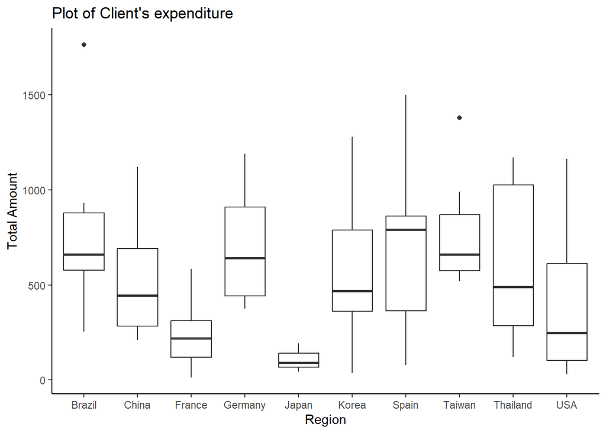

```r
library(ggplot2)
ggplot(full_table2_female,aes(x=Region, y=Spend)) +
  geom_boxplot() +
  labs(title="Plot of Client's expenditure",x="Region", y = "Total Amount")+
  theme_classic()
```